# Effects of urban green infrastructure on supply provision of ecosystem service: temperature regulation

Irina Lerner

30/01/24

# Introduction

Urban areas, while only occupying 2% of the Earth’s surface, impact deeply the environment, significantly affecting biodiversity [1] and human health and well-being [2]. Today, over half of the global population lives in urban centers, projected to rise to 70% by 2070 [3], especially in developing countries with limited infrastructure [4]. Despite the recognized benefits of urban green spaces for public health and species preservation, balancing spatial occupation with environmental conservation remains a challenge [5].

Green urban infrastructure extends beyond sheer vegetation quantity; it includes aspects of configuration, fragmentation, and type [5]. The concept of a space use gradient, originally developed to balance nature conservation and agricultural yield [6], can be modified to model conservation in urban settings, where this gradient is mirrored by population density variations, from total conservation of one area to total use elsewhere (sparing), passing through to moderate, uniform use (sharing) [7].

This study investigates how these different spatial configurations impact the benefits to human life that nature provides - the ecosystem services (E.S.) specifically, surface temperature regulation, scenic beauty, and recreation, in São Paulo for its importance as an urban center in a developing country such as Brazil. We hypothesize that the degrees of sharing and sparing directly influence the supply, flow, and demand of these services, aiming to inform sustainable urban vegetation management for optimized E.S. provision.

# Methodology

## Roadmap

We compare variables in statistical models to explore the relationship between the configuration of green infrastructure in an urban landscape and the supply of surface temperature regulation, scenic beauty and recreation. To model both the configuration of green spaces and E.S.’s supply, we subdivide the urban center of São Paulo into regions and assign sharing and sparing indexes, derived from vegetation data (fig 1, table 1) and indexes temperature variation, perception of beauty and availability of recreation spaces (fig 2, table 2).

## Landscape metrics

[figure not shown]

SP

**Figure 1**: (I) Map of São Paulo’s Enhanced Vegetation Index (EVI) and 1km² grid with regions of analysis. (II) A single grid cell and its corresponding resolution. For EVI, each 30m² cell is colored in a shade from green to red according to the amount of vegetation. (III) Histogram of grid II categorized in low (A), medium (B) and high (C) vegetation density. [8]

**Table 1**. Calculation of sharing and sparing indexes based on São Paulo’s EVI. SVI = Sharing Vegetation index, SGVI = Sparing Green Vegetation Index, SUVI = Sparing Urban Vegetation Index, SEVI = Sparing Evenness Vegetation indexes. They represent proportions of areas of only urban, sharing and only green, and the balance between green and urban.

| Index | Formula | Description |
| --- | --- | --- |
| SVI | $\frac{B}{(A + B + C)}$ | Proportion of areas with medium EVI (0,16 to 0,56) |
| SGVI | $\frac{C}{(A + B + C)}$ | Proportion of areas with high EVI (higher than 0,56) |
| SUVI | $\frac{A}{(A + B + C)}$ | Proportion of areas with low EVI (lower than 0,16) |
| SEVI | $\bigg(\frac{(A-C)}{(A+C)} + 1\bigg)\frac{1}{2}$ | Normalized difference between the proportion of high and low vegetation areas |

For now, I’m not really sure I’ll be using all the indexes. I still have to do some analysis to see what the best models look like.

## Ecosystem Services

[figure not shown]

**Figure 2**: E.S. provision can be modeled as a graph where areas of demand (cities) and supply (vegetation) of different sizes are connected by the flow - how supply gets to the demand.

| Service | Supply | Demand | Flow | Provision |
| --- | --- | --- | --- | --- |
| Surface temperature regulation | ΔTmax = T*max - Tmax | population | local | S x D |
| Scenic beauty | Estimated perception of beauty | population | local | S x D |
| Biodiversity | Number of species seen | (support service) | S |  |

## Statistical Analysis

**Framework:** generalized linear mixed model (GLMM) with both random and fixed effects (FitMe from SpaMM package in R)

**Response variables (Y):** supply and provision of each service (tbl 2)

**Predictor variables (X):** sharing and sparing indexes, relationships and proportion of vegetation

**Fixed effects (fe):** depends on the service

**Random effects (re):** distance betwwen grid’s centroids as a matrix Models were compared with Akaike’s Information Criteria (AIC)

## Data

The data for analysis was produced by Douglas Cirino and Arthur Lupinetti and treated by me.

```r
shp$sp_codigo <- shp$RM
# remove isolated places and add centroids to data
data <- edit_shp(shp)
#data_urban <- data_urban[data_urban$prop_veg > 0.3,]
data_total <- as.data.frame(data)
data_total$SIVI2 <- 1 - data_total$SIVI
data_total$SEVI <- data_total$SIVI2
data_total$DT_supply <- data_total$DT
```

## Exploratory analysis

### Correlations

```
## [1] "SUVI"     "SVI"      "SGVI"     "SEVI"     "prop_veg"
```

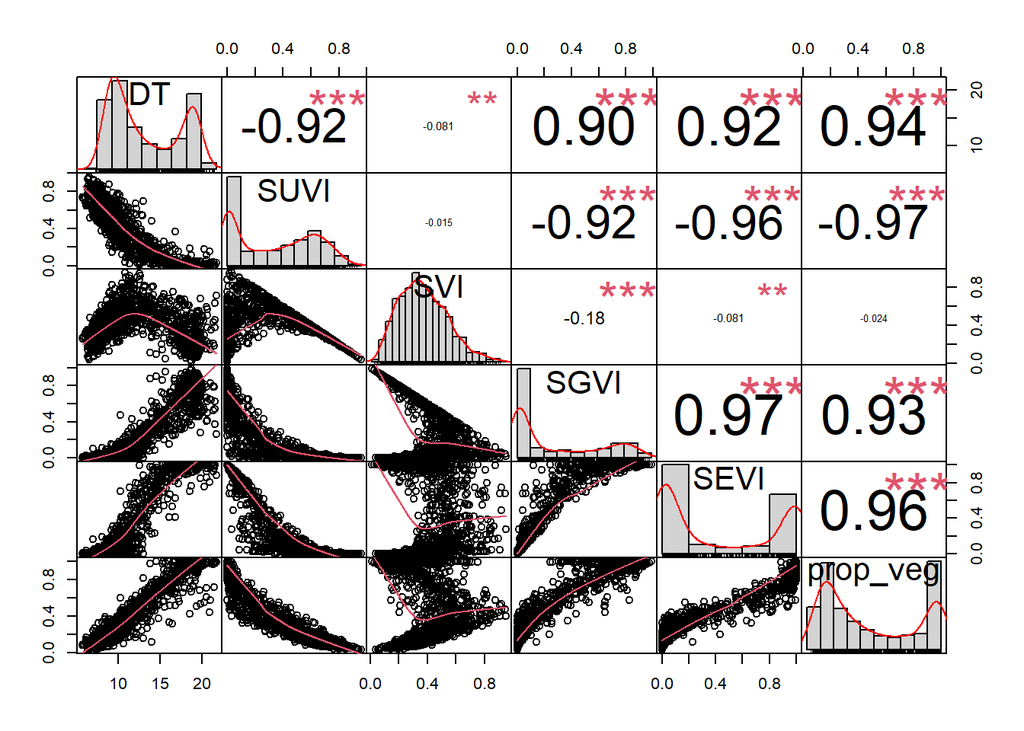

Since the landscape metrics are proportion of space, they’re highly correlated.

### Dealing with Collinearity:

Principal Component Analysis (PCA): Since you have highly collinear variables, PCA can be a good method to reduce dimensionality. This technique transforms your correlated variables into a set of uncorrelated principal components. Might complicate analysis

### Models for the whole city

For the total city dataset we will run all the possible models with non-colinear predictors, and compare both mAIC and cAIC for those models. I am yet to figure out what each really represents and wich models to include.

```
## [1] "mAIC"
```

```
##             Model      AIC  deltaAIC             w  evidence
## 9      SVI * SEVI 3128.631    0.0000  1.000000e+00 1.0000000
## 8  SVI + prop_veg 3253.916  125.2854  6.231934e-28 0.9614970
## 10 SVI * prop_veg 3255.604  126.9731  2.679990e-28 0.9609986
## 6        prop_veg 3259.623  130.9923  3.592439e-29 0.9598137
## 3            SEVI 3537.683  409.0517  1.498121e-89 0.8843730
## 7      SVI + SEVI 3539.576  410.9454  5.812194e-90 0.8838998
## 5            SGVI 3777.886  649.2555 1.037437e-141 0.8281432
## 4            SUVI 3790.253  661.6221 2.140827e-144 0.8254412
## 2             SVI 4716.323 1587.6922  0.000000e+00 0.6633623
## 1               1 4716.591 1587.9600  0.000000e+00 0.6633246
```

[output not shown]

```
##             Model       AIC  deltaAIC             w  evidence
## 1               1 -4697.508    0.0000  1.000000e+00  1.000000
## 2             SVI -3748.369  949.1389 7.890634e-207  1.253214
## 4            SUVI -2162.851 2534.6570  0.000000e+00  2.171906
## 5            SGVI  1836.538 6534.0461  0.000000e+00 -2.557805
## 3            SEVI  2101.232 6798.7399  0.000000e+00 -2.235597
## 7      SVI + SEVI  2122.782 6820.2900  0.000000e+00 -2.212901
## 9      SVI * SEVI  2140.076 6837.5838  0.000000e+00 -2.195019
## 6        prop_veg  2480.941 7178.4483  0.000000e+00 -1.893438
## 8  SVI + prop_veg  2492.751 7190.2584  0.000000e+00 -1.884467
## 10 SVI * prop_veg  2493.488 7190.9960  0.000000e+00 -1.883910
```

We can see that cAIC and mAIC have different results. Apparently, the spatial component is important because cAIC is lower than mAIC. In the effects we include microclimatic region, so this might have an effect - yet to see.

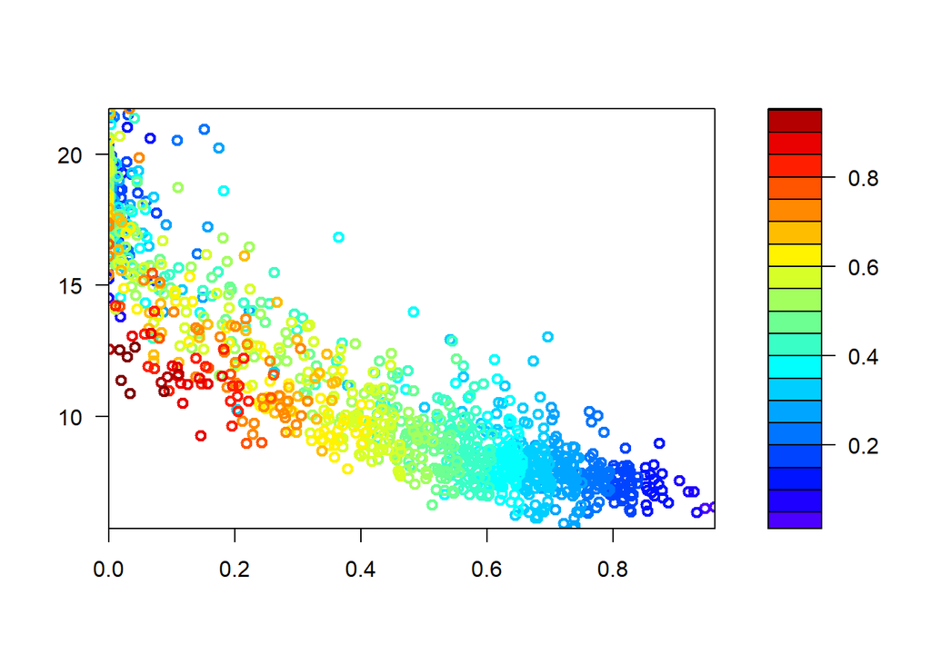

```r
spaMMplot2D(data_total$SUVI, data_total$DT, data_total$SVI)
```

### Controling for proportion of vegetation

Now we will consider three vegetation segments: 0 to 0.3 vegetation, a situation that cannot sustain biodiversity. 0.3 to 0.6 urban vegetated and can sustain biodiversity. 0.6 to 1 it’s not urban anymore.

```r
data_1 <- data_total[data_total$prop_veg <= 0.3,]
data_2 <- data_total[data_total$prop_veg > 0.3,]
data_2 <- data_2[data_2$prop_veg <= 0.6,]
data_3 <- data_total[data_total$prop_veg > 0.6,]
```

For the urab part of the city:

```
## [1] "mAIC"
```

```
##             Model      AIC  deltaAIC             w  evidence
## 9      SVI * SEVI 1052.898   0.00000  9.991073e-01 1.0000000
## 7      SVI + SEVI 1066.939  14.04084  8.926513e-04 0.9868401
## 8  SVI + prop_veg 1092.608  39.71011  2.380514e-09 0.9636557
## 10 SVI * prop_veg 1094.412  41.51396  9.659834e-10 0.9620673
## 6        prop_veg 1096.590  43.69226  3.250566e-10 0.9601563
## 4            SUVI 1158.681 105.78285  1.069445e-23 0.9087040
## 3            SEVI 1237.980 185.08256  6.448298e-41 0.8504964
## 2             SVI 1250.106 197.20810  1.501125e-43 0.8422469
## 5            SGVI 1259.661 206.76273  1.263735e-45 0.8358584
## 1               1 1517.632 464.73399 1.213131e-101 0.6937768
```

```
## [1] "cAIC"
```

```
##             Model         AIC  deltaAIC             w  evidence
## 7      SVI + SEVI -3802.17260    0.0000  1.000000e+00  1.000000
## 1               1 -3699.66403  102.5086  5.502332e-23  1.027708
## 9      SVI * SEVI -3128.09951  674.0731 4.235322e-147  1.215490
## 2             SVI -2975.75609  826.4165 3.515064e-180  1.277716
## 3            SEVI -2853.59033  948.5823 1.042260e-206  1.332417
## 5            SGVI -2668.91611 1133.2565 8.250466e-247  1.424613
## 4            SUVI -2444.59943 1357.5732 1.609651e-295  1.555336
## 6        prop_veg  -119.34636 3682.8262  0.000000e+00 31.858303
## 10 SVI * prop_veg   -78.44380 3723.7288  0.000000e+00 48.470021
## 8  SVI + prop_veg   -45.25772 3756.9149  0.000000e+00 84.011589
```

```r
fixef(best_1)
```

```
## (Intercept)         SVI        SEVI
##    7.347430    3.333282    8.141557
```

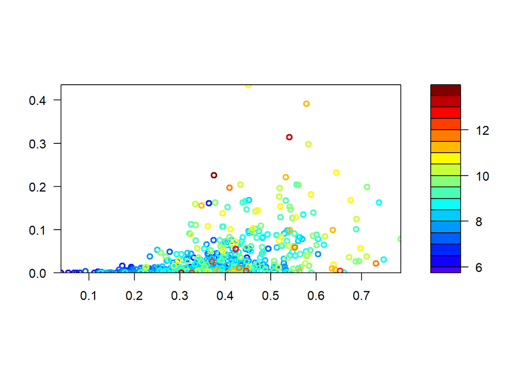

```r
spaMMplot2D(data_1$SVI, data_1$SEVI, data_1$DT)
```

Then, for the greener space

```
## [1] "mAIC"
```

```
##             Model      AIC  deltaAIC            w  evidence
## 9      SVI * SEVI 707.6603   0.00000 9.999498e-01 1.0000000
## 5            SGVI 727.4586  19.79830 5.021475e-05 0.9727843
## 7      SVI + SEVI 755.9620  48.30167 3.246405e-11 0.9361057
## 3            SEVI 768.1613  60.50105 7.283521e-14 0.9212391
## 10 SVI * prop_veg 783.7622  76.10190 2.983047e-17 0.9029018
## 8  SVI + prop_veg 788.0269  80.36659 3.536679e-18 0.8980154
## 6        prop_veg 797.0599  89.39957 3.864631e-20 0.8878383
## 4            SUVI 822.1846 114.52433 1.353121e-25 0.8607073
## 2             SVI 904.8450 197.18475 1.520038e-43 0.7820790
## 1               1 905.4561 197.79580 1.119864e-43 0.7815512
```

[output not shown]

```
##             Model        AIC  deltaAIC            w  evidence
## 1               1 -1094.7705    0.0000 1.000000e+00  1.000000
## 2             SVI  -924.3117  170.4588 9.667998e-38  1.184417
## 4            SUVI   404.2193 1498.9899 0.000000e+00 -2.708358
## 9      SVI * SEVI   598.6572 1693.4277 0.000000e+00 -1.828710
## 5            SGVI   601.3751 1696.1457 0.000000e+00 -1.820445
## 6        prop_veg   627.8836 1722.6541 0.000000e+00 -1.743588
## 8  SVI + prop_veg   651.7454 1746.5160 0.000000e+00 -1.679752
## 7      SVI + SEVI   653.6190 1748.3895 0.000000e+00 -1.674937
## 10 SVI * prop_veg   658.5946 1753.3652 0.000000e+00 -1.662283
## 3            SEVI   666.6408 1761.4113 0.000000e+00 -1.642220
```

```r
fixef(best_2)
```

```
## (Intercept)         SVI        SEVI    SVI:SEVI
##    8.296629    2.915266   12.000148  -11.625423
```

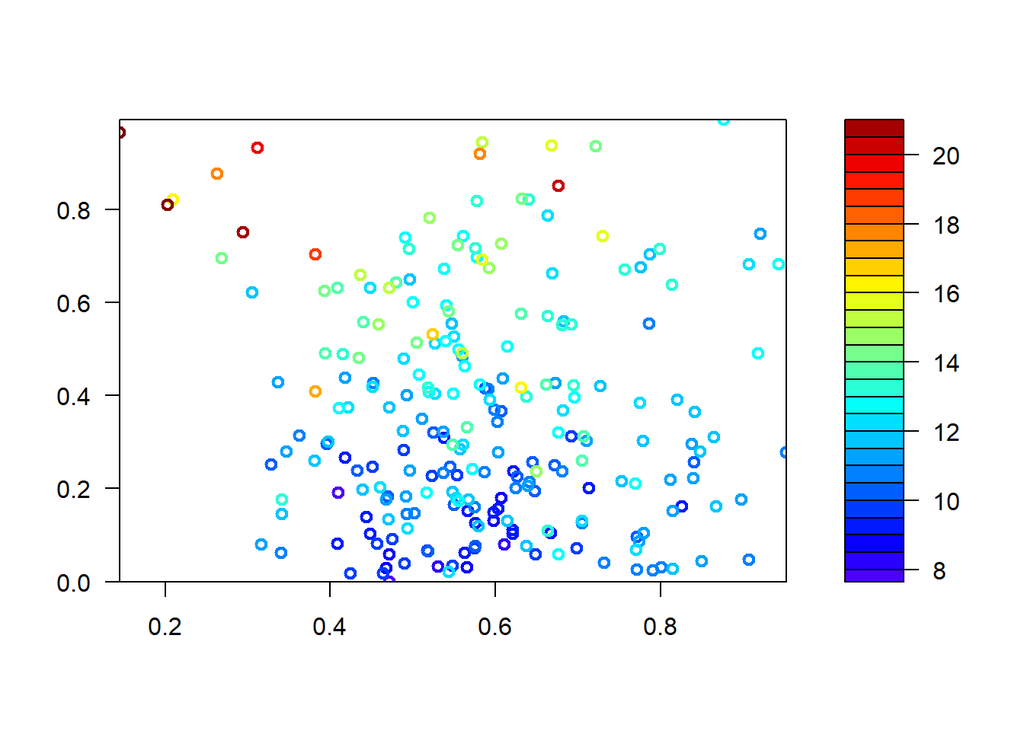

```r
spaMMplot2D(data_2$SVI, data_2$SEVI, data_2$DT)
```

and at last, for the non-urban vegetated areas

```
## [1] "mAIC"
```

[output not shown]

```
## [1] "cAIC"
```

[output not shown]

```r
fixef(best_3)
```

```
## (Intercept)         SVI        SEVI
##   12.297895   -2.539202    6.058543
```

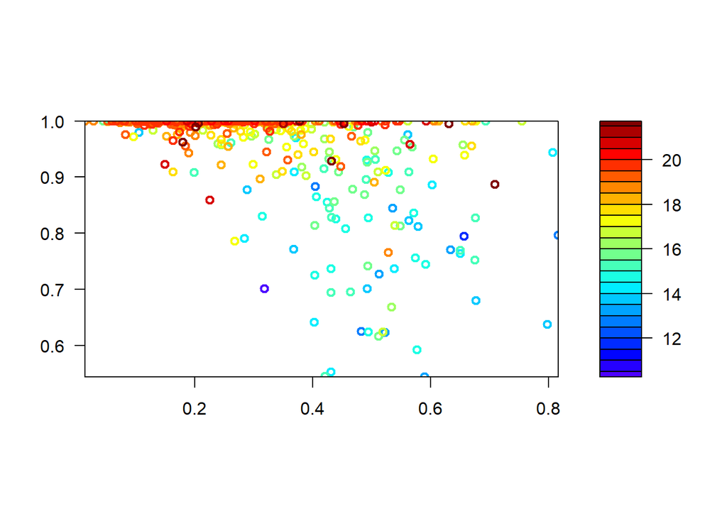

```r
spaMMplot2D(data_3$SVI, data_3$SEVI, data_3$DT)
```

# References

[1] Simkin et al. (2022). Biodiversity impacts and conservation implications of urban land expansion. Proc Natl Acad Sci, 119(12).

[2] Goldstein (1990). Urbanization, health and well-being. J R Stat Soc Ser D (The Statistician), 39(2), 121-133.

[3] WHO (2010). Urbanization and health. Bull World Health Organ, 88(4), 245-246.

[4] Cohen (2006). Urbanization in developing countries. Technol Soc, 28(1-2), 63-80.

[5] Semeraro et al. (2021). Planning of urban green spaces. Land, 10(2), 105.

[6] Green et al. (2005). Farming and the fate of wild nature. Science, 307(5709), 550-555.

[7] Lin & Fuller (2013). How should we grow the world’s cities? J Appl Ecol, 50(5)

[8] Cirino et al (2022). Balanced spatial distribution of green areas creates healthier urban landscapes. J Appl Ecol 59.7